# Investigating the Case of Jack the Ripper with Data Mining

### Introduction

**The Case of Jack the Ripper:**

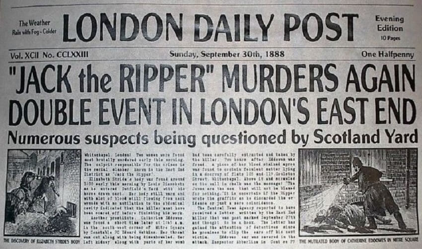

In 1888, an unknown killer caused fear and mayhem in the streets of London after five women were murdered. The killer was known only to the public as Jack the Ripper. Jack the Ripper is one of the most famous unsolved mysteries of all time. This case has perplexed detectives and scholars alike for the past 130 years. The authorities of the time had unsophisticated techniques for collecting evidence and were never able to narrow in on one suspect. Very little still exists that might be able to finally catch this age-old killer. Jack the Ripper often taunted the investigators of his (or possibly her) crimes through letters, and these letters still exist to this day. Through using data mining techniques, we will compare the famous Jack the Ripper letters with writings and other forms of prose from known suspects and see if a prolific killer is among them.

### Primary Source Documents

- The three Canonical Jack the Ripper Letters

[figure not shown]

- Writings and Quotes from six suspects
  - Prince Albert Victor
  - Lewis Carroll
  - Joseph Barnett
  - Carl Feigenbaum
  - Mary Pearcey
  - Walter Sickert

We began our data collection process by acquiring the texts from the original Jack the Ripper. Then, we put the letters into individual text files. Next, We researched prominent suspects in the Jack the Ripper case. Once we located the suspects, we then acquired writing and quotes by these suspects. Our data set includes writings, testimonies and quotes from 6 different suspects. All suspect primary source documents were broken into individual text files.